# ISE 537 Assignment 1

Smith, Keenan

“Built with R Version 4.1.2”

# Section 1

1. The estimated simple linear regression coefficient 𝛽0, measures the strength of a linear relationship between the predicting and response variables.
- False
2. In simple linear regression, a negative value of 𝛽1 is consistent with an inverse relationship between the predicting variable and the response variable.
- True
3. In simple linear regression, 𝛽0 is an unbiased estimator for 𝛽0.
- True
4. If the assumptions of a simple linear regression model hold, then the estimator for the variance of the error terms, 𝜎2 is a random variable.
- False
5. Under the normality assumption, the estimated simple linear regression coefficient, 𝛽1, is a linear combination of normally distributed random variables.
- True
6. The p-value is a measure of the probability of rejecting the null hypothesis.
- False
7. In simple linear regression, the prediction interval of one member of the population will always be wider than the confidence interval of the mean response for all members of the population when using the same predicting value.
- True
8. In simple linear regression, the normality assumption states that the response variable is normally distributed.
- True

# Section 2

### Package Initiation Block

```r
# Initiate Tidyverse since all relevant packages are located within
library(tidyverse)
```

### Data Import and Function Definition

Function for Regression Model source https://sejohnston.com/2012/08/09/a-quick-and-easy-function-to-plot-lm-results-in-r/

```r
# Importing machine.csv in a dplyr dataframe
machine <- read_csv("machine.csv", show_col_types = FALSE)
# Inspecting Dataframe to ensure good import
head(machine)
```

```
## # A tibble: 6 x 3
##   vendor  chmax performance
##   <chr>   <dbl>       <dbl>
## 1 adviser   128         198
## 2 amdahl     32         269
## 3 amdahl     32         220
## 4 amdahl     32         172
## 5 amdahl     16         132
## 6 amdahl     32         318
```

```r
# ggplot Regression Function for a Nicer Looking Plot
gg_plot_regression <- function(fit) {
  require(ggplot2)

  ggplot(fit$model, aes_string(
    x = names(fit$model)[2],
    y = names(fit$model)[1]
  )) +
    geom_point() +
    stat_smooth(method = "lm", col = "red") +
    labs(title = paste(
      "Adj R2 = ", signif(summary(fit)$adj.r.squared, 5),
      "Intercept =", signif(fit$coef[[1]], 5),
      " Slope =", signif(fit$coef[[2]], 5),
      " P =", signif(summary(fit)$coef[2, 4], 5)
    ))
}
```

## 2.1 Exploratory Data Analysis

1. Use a scatter plot to describe the relationship between CPU performance and the maximum number of channels. Describe the general trend (direction and form). Include plots and R-code used. Exploratory Data Plotting

```r
summary(machine)
```

```
##     vendor              chmax         performance
##  Length:209         Min.   :  0.00   Min.   :   6.0
##  Class :character   1st Qu.:  5.00   1st Qu.:  27.0
##  Mode  :character   Median :  8.00   Median :  50.0
##                     Mean   : 18.27   Mean   : 105.6
##                     3rd Qu.: 24.00   3rd Qu.: 113.0
##                     Max.   :176.00   Max.   :1150.0
```

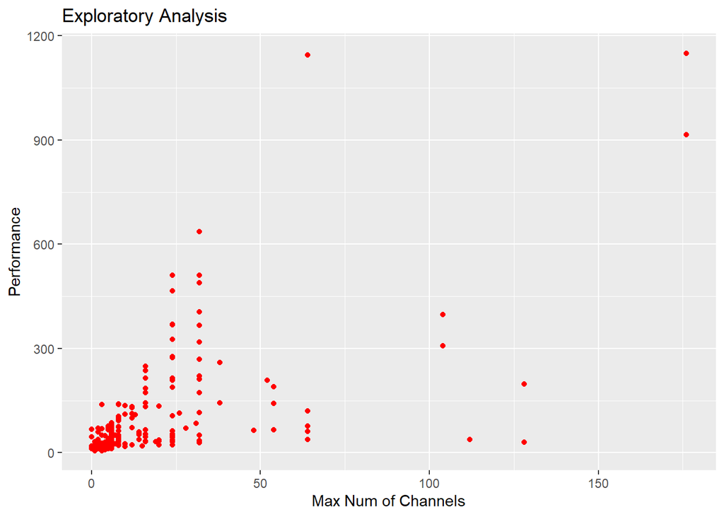

```r
max_performance <- ggplot(data = machine, aes(x = chmax, y = performance)) +
  geom_point(color = "red") +
  labs(
    x = "Max Num of Channels", y = "Performance",
    title = "Exploratory Analysis"
  )

max_performance
```

2. What is the value of the correlation coefficient between performance and chmax? Please interpret the strength of the correlation based on the correlation coefficient. Correlation Coefficient Calculation

```r
chmax_vec <- machine %>%
  pull(var = 2)

performance_vec <- machine %>%
  pull(var = 3)

correlation_ch_perf <- cor(x = chmax_vec, y = performance_vec)
correlation_ch_perf
```

```
## [1] 0.6052093
```

3. Based on this exploratory analysis, would you recommend a simple linear regression model for the relationship?
- Based on the correlation coefficient of ~ 0.61, their is a moderate to moderate-strong positive association between the number of channels and performance. A linear model should be explored to analyze further values.

## Section 2.2 Linear Model

Fitting a Linear Model to the Data

```r
performance_lm <- lm(performance ~ chmax, data = machine)

summary(performance_lm)
```

```
##
## Call:
## lm(formula = performance ~ chmax, data = machine)
##
## Residuals:
##     Min      1Q  Median      3Q     Max
## -486.47  -42.20  -22.20   20.31  867.15
##
## Coefficients:
##             Estimate Std. Error t value Pr(>|t|)
## (Intercept)  37.2252    10.8587   3.428 0.000733 ***
## chmax         3.7441     0.3423  10.938  < 2e-16 ***
## ---
## Signif. codes:  0 '***' 0.001 '**' 0.01 '*' 0.05 '.' 0.1 ' ' 1
##
## Residual standard error: 128.3 on 207 degrees of freedom
## Multiple R-squared:  0.3663, Adjusted R-squared:  0.3632
## F-statistic: 119.6 on 1 and 207 DF,  p-value: < 2.2e-16
```

```r
beta1_95 <- confint(performance_lm, level = 0.95)
beta1_99 <- confint(performance_lm, level = 0.99)

beta1_95
```

```
##                 2.5 %    97.5 %
## (Intercept) 15.817392 58.633048
## chmax        3.069251  4.418926
```

```r
beta1_99
```

```
##                0.5 %    99.5 %
## (Intercept) 8.994891 65.455549
## chmax       2.854185  4.633991
```

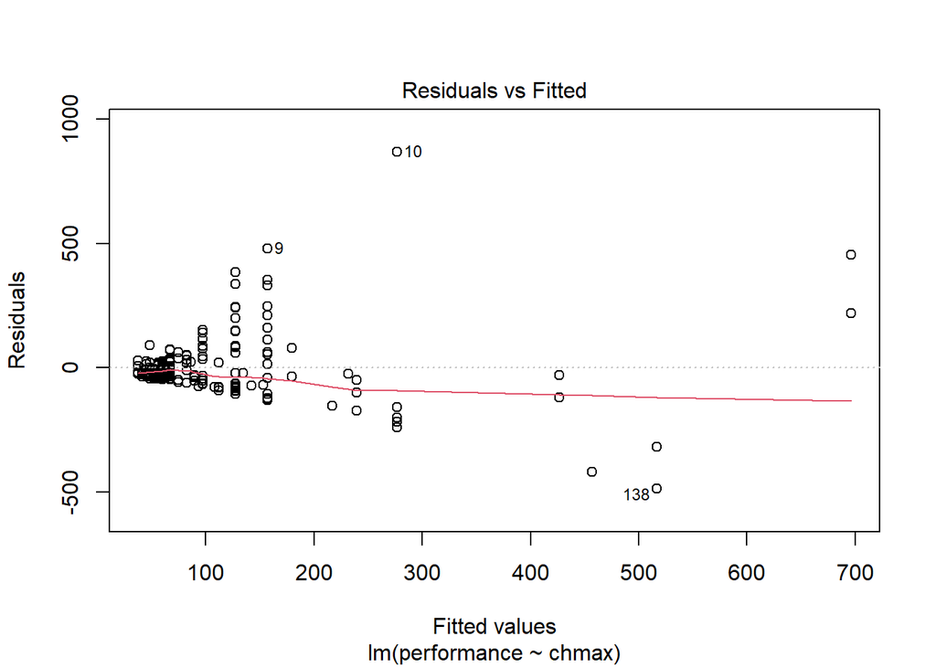

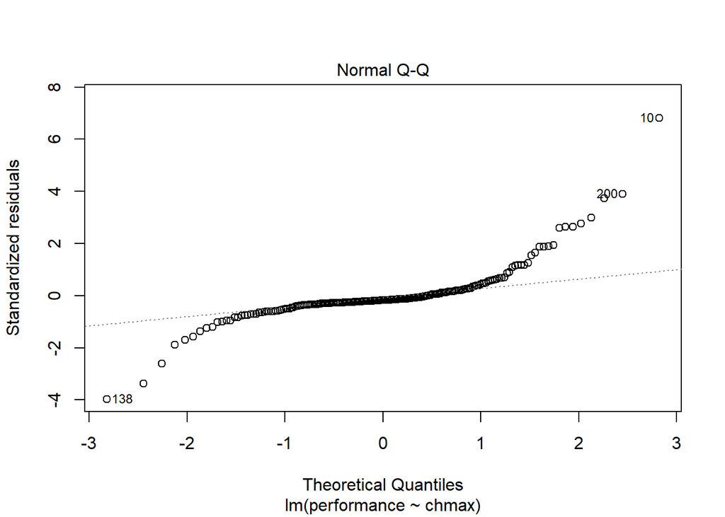

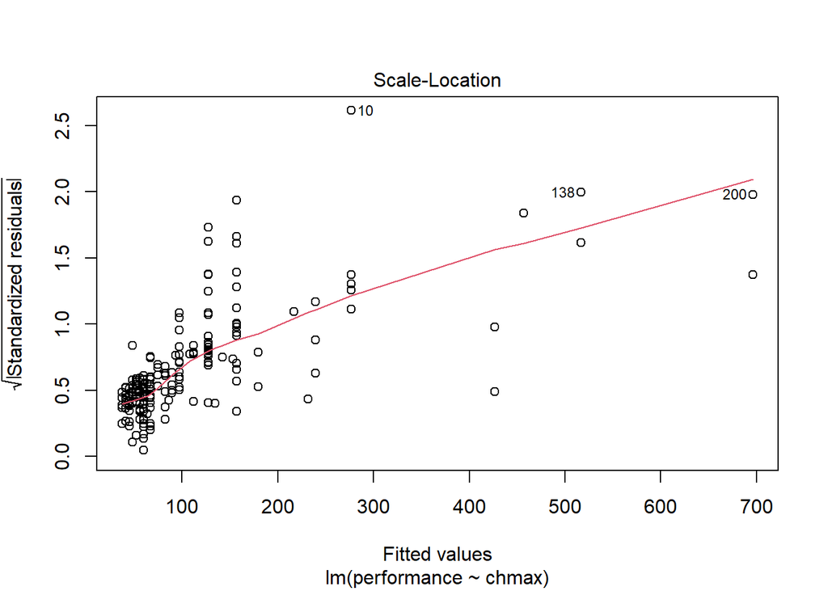

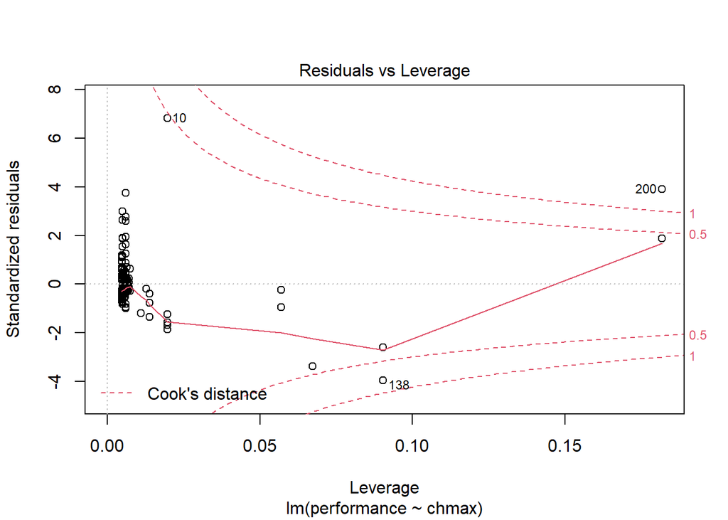

```r
plot(performance_lm)
```

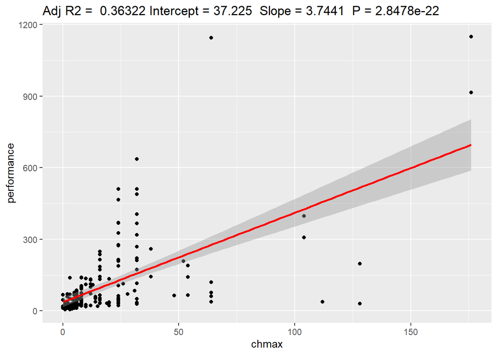

```r
gg_plot_regression(performance_lm)
```